# model-performance-rpart

Madhuri Kalani

April 21, 2018

## Loading the Project

The first step of model training is to load the project. It includes installing all the necessary libraries and data munging to prepare the training and test data sets, doing exploratory data analysis to study the data and feature selection.

## Model Training using rpart

The caret package in R provides a powerful framework for growing classification trees.

```r
#Tree Model to Classify - rpart


train_control <- trainControl(method="cv", number=3)
model_rpart <- train(as.factor(is_attributed)~app + channel + ip +device + os + click_time, data=df.train, method="rpart", trControl=train_control)
```

### Summary of Trained Rpart

```
## CART
##
## 69743 samples
##     6 predictor
##     2 classes: '0', '1'
##
## No pre-processing
## Resampling: Cross-Validated (3 fold)
## Summary of sample sizes: 46495, 46496, 46495
## Resampling results across tuning parameters:
##
##   cp           Accuracy   Kappa
##   0.002732240  0.9974908  0.8712595
##   0.003317721  0.9974478  0.8683143
##   0.769125683  0.9948382  0.5759161
##
## Accuracy was used to select the optimal model using the largest value.
## The final value used for the model was cp = 0.00273224.
```

### Plotting the Trained Model

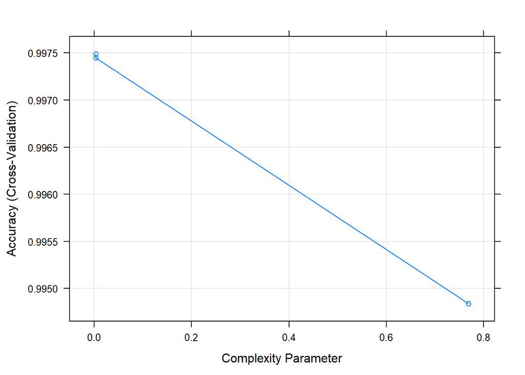

### Fitting the Trained rpart Model

It is a tabular representation of Actual vs Predicted values. This helps to find the accuracy of the model and avoid overfitting.

```
## [1] "Confusion Matrix for tree: rpart"
```

```
## Confusion Matrix and Statistics
##
##    predict_rpart
##         0     1
##   0 29605    17
##   1    45   223
##
##                Accuracy : 0.9979
##                  95% CI : (0.9973, 0.9984)
##     No Information Rate : 0.992
##     P-Value [Acc > NIR] : < 2.2e-16
##
##                   Kappa : 0.8769
##  Mcnemar's Test P-Value : 0.0006058
##
##             Sensitivity : 0.9985
##             Specificity : 0.9292
##          Pos Pred Value : 0.9994
##          Neg Pred Value : 0.8321
##              Prevalence : 0.9920
##          Detection Rate : 0.9905
##    Detection Prevalence : 0.9910
##       Balanced Accuracy : 0.9638
##
##        'Positive' Class : 0
##
```

### Step 2 Finding Cohen’s Kappa

```
## [1] "Kappa value for tree: rpart"
```

```
##     Kappa
## 0.8769099
```

### Step 3 Finding Accuracy Value

```
## [1] "Accuracy value for tree: rpart"
```

```
##  Accuracy
## 0.9979257
```

### Step 4 Building a ROC Curve

An ROC curve demonstrates several things for 2-class classification algorithms:

It shows the tradeoff between sensitivity and specificity (any increase in sensitivity will be accompanied by a decrease in specificity). The closer the curve follows the left-hand border and then the top border of the ROC space, the more accurate the test. The closer the curve comes to the 45-degree diagonal of the ROC space, the less accurate the test.

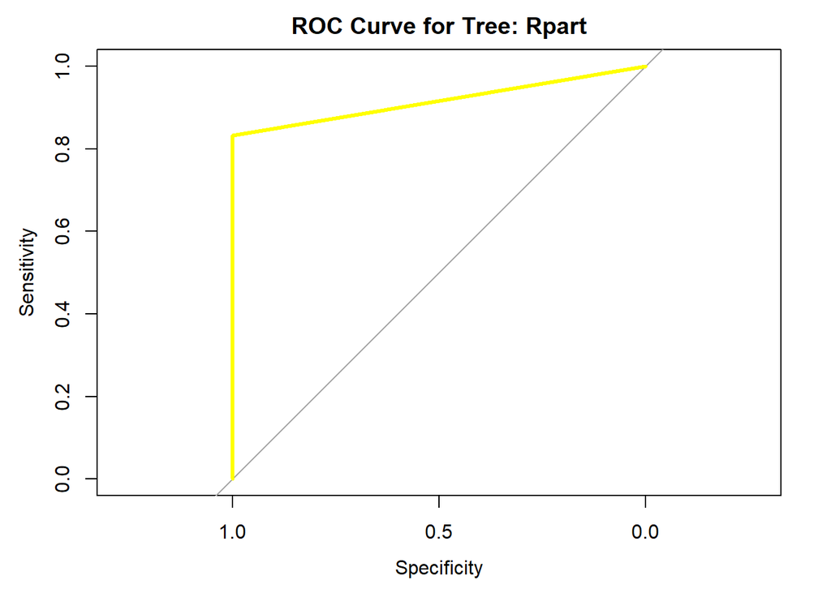

## rpart function did not show the outcome as expected